# PHYS 210 Lecture 02 - Sept 08, 2025

Agenda:

1. About my winding road
2. Reading 02: Recap, Q&A and Polling Questions
3. How group worksheets work
4. The rest of today

## My winding road: I didn't start out as a Physics major

[figure not shown]

## Reading 02: Recap, Q&A and Polling Questions

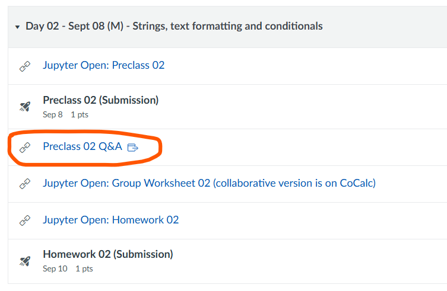

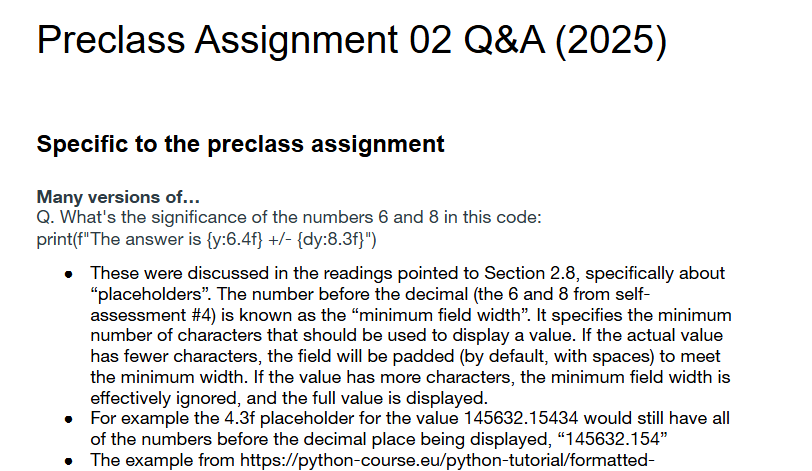

### String formatting (3 styles)

Percent-style (%) string formatting (old style)

```
print("The answer is %6.4f +/- %8.3f" % (y, dy) )
```

str.format() (new style)

```
print("The answer is {:6.4f} +/- {:8.3f}".format(y, dy))
```

f-strings

```
print(f"The answer is {y:6.4f} +/- {dy:8.3f}")
```

LOTS of questions about this one:

**Q.** What's the significance of the numbers 6 and 8 in this code: print(f"The answer is {y:6.4f} +/- {dy:8.3f}")

### From Self-assessment Q4

What will the following output?

```python
y = 9.47
dy = 0.58293
print(f"The answer is {y:6.4f} +/- {dy:8.3f}")
```

The `n` in `{dy:n.3f}` is the *minimum field width*

- Specifies minimum number of characters to display a value.
- If the actual value has fewer the field will be padded with spaces to meet minimum width.
- If the actual value has more characters, minimum field width is ignored and the full value is displayed.
- `n` does not have to be specified, e.g., `{dy:.3f}`

**Polling Q1:** Which choice will give the following output (two blank spaces)?  
`tau:⎵⎵6.28`

```python
tau = 6.283185307179586

print(f"tau: {tau:4.2f}") # A
print(f"tau: {tau:5.2f}") # B
print(f"tau: {tau:6.2f}") # C
print(f"tau:{tau:6.2f}")  # D
# More than one of these  # E
```

Why would you ever need this space padding? A useful example from https://www.pythonmorsels.com/string-formatting/

**Example:** a list of numbers formatted to be space-padded to 2 characters

```python
tracks = [(1, "Harlem"), (3, "Grandma's Hands"), (10, "Moanin' and Groanin'")]
for n, title in tracks:
    print(f"{n:2d}. {title}")
```

```
 1. Harlem
 3. Grandma's Hands
10. Moanin' and Groanin'
```

```python
tracks = [(1, "Harlem"), (3, "Grandma's Hands"), (10, "Moanin' and Groanin'")]
for n, title in tracks:
    print(f"{n:02d}. {title}")
```

```
01. Harlem
03. Grandma's Hands
10. Moanin' and Groanin'
```

**Q:** What's the difference between `{tau:.3f}` and `{tau:.3}`?

```python
tau = 6.283185307179586
print(f"{tau:.3f}") # 3 decimal places
print(f"{tau:.3}")  # 3 significant figures
```

```
6.283
6.28
```

**See if you can answer your own questions:** The preclass points you toward additional resources

> To gain a better understanding of placeholders and some of the syntax of the str.format() and % operator approaches, read through the following (stop when you get to "Using dictionaries in "format")
> - https://python-course.eu/python-tutorial/formatted-output.php
> - As an additional resource with a lot of examples, you can also have a look at https://pyformat.info/

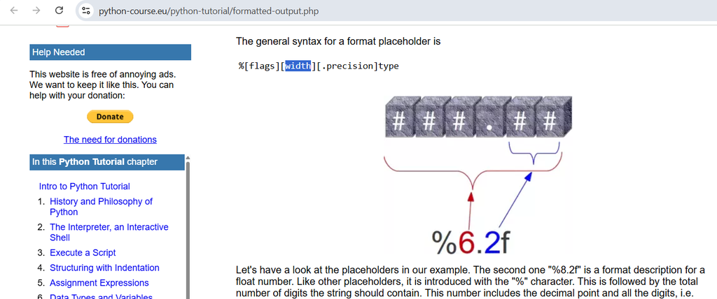

> **GenAI prompt:** Explain what the 6 and 8 mean in the following: print(f"The answer is {y:6.4f} +/- {dy:8.3f}")

General format: **{value:width.precisionf}**

- **width (1st number)** → minimum number of characters reserved for the output.
- **precision (number after the dot)** → how many digits to display after the decimal point.
- **f** → fixed-point notation (decimal numbers, not scientific notation).

{dy:8.3f}

- 8 → reserve at least 8 characters of space.
- .3f → print 3 digits after the decimal.

Example:

```
dy = 12.3456
print(f"{dy:8.3f}")  # -> '  12.346'
```

Two spaces are added before because the number itself is only 6 characters (12.346).

✅ So in summary:

- The 6 and 8 specify the minimum field widths.
- The 4 and 3 specify the number of digits after the decimal point.

Would you like me to also show what happens if the number is longer than the width (e.g., y = 12345.6789)?

[figure not shown]

### String indexing and slicing

**Q.** Please review how negative slicing works!

### String indexing (extracting a single character from a string)

Indexing: extracting a single character from a string

```python
my_string = "Rainy days"
print(my_string[2])
print(my_string[2:3]) # Same as the one above
print(my_string[-2])
```

```
i
i
y
```

### String slicing (extracting a portion of a string)

**Polling Q2:** How do we print `y d`?

```python
my_string = "Rainy days"

print(my_string[3:5])  # A
print(my_string[3:6])  # B
print(my_string[4:6])  # C
print(my_string[4:7])  # D
# None of these        # E
```

We can also use negative index slicing

```python
my_string = "Rainy days"

print(my_string[-6:])
print(my_string[:-3])
print(my_string[-6:-3])
print(my_string[-6:7])
```

### See the Q&A for a longer example of how to extract 'oo' backward from 'Hello World!'

**Polling Q3:** Will the print statement happen?

```python
if (9//2 > 4):
    print("Yes, we got in!")
```

A) Yes  
B) No

## How group worksheets work

### Finding your group worksheets on CoCalc

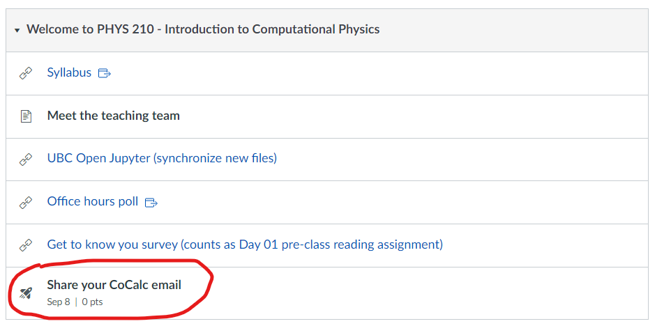

[figure not shown]

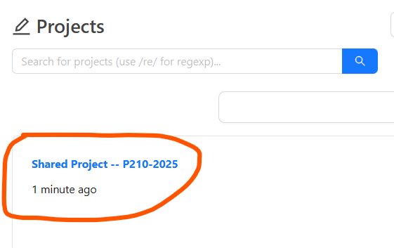

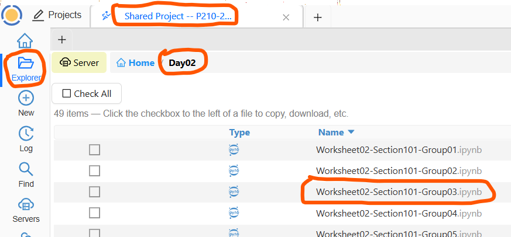

### Rename the worksheet with a fun group name

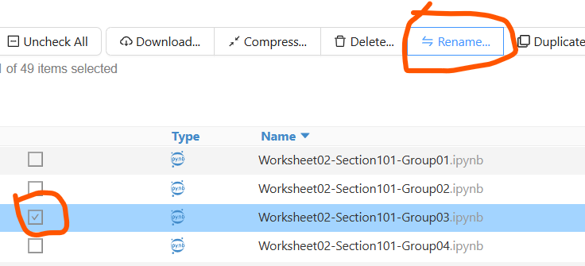

### You can work on CoCalc or download the worksheet and work elsewhere

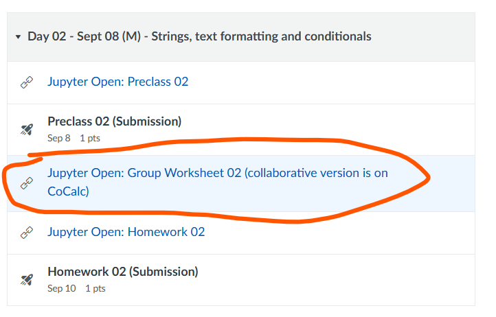

### Add your names so you can easily identify your worksheet in the future

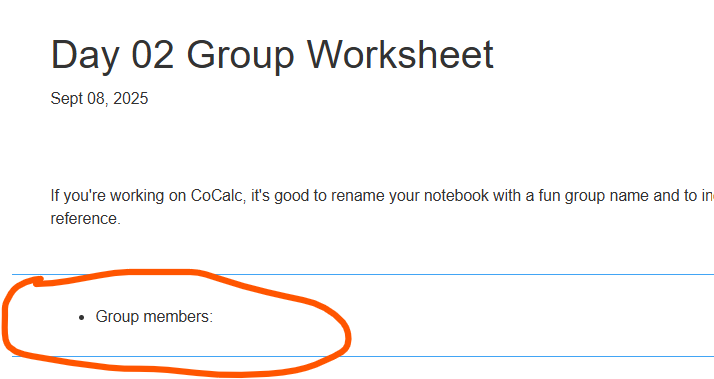

**Once you have completed the group worksheet:**  
Call one of us over to ask each of you a question. If you have trouble answering a question, we'll leave and come back to ask again after you've had a chance to discuss things with your group.

## The rest of today

- Group Worksheet 02
  - Make sure your group answers questions with a TA or me to earn engagement credit
- And then move onto Homework 02
- Preclass 03 by 7am on Wednesday